# a3_task4_logan_babcock.Rmd

Logan Babcock

10/27/2021

### Introduction

This is the code for the analysis of urchin size data taken from various sites from 2001-2012, but here we are specifically looking at data for the 2010 Naples Reef treatment site for the Purple Urchin Species.

*Data Citation:* Reed, D. 2020. SBC LTER: Reef: Long-term experiment: Kelp removal: Urchin size frequency distribution ver 20. Environmental Data Initiative. https://doi.org/10.6073/pasta/5a1e9ef03aa47bd2225c0bb98a02a63b

### Exploring the data: Using exploratory graphs

Here we use exploratory (informal and informational) graphs to explore the distribution of the data, and make observations about trends that are revealed.

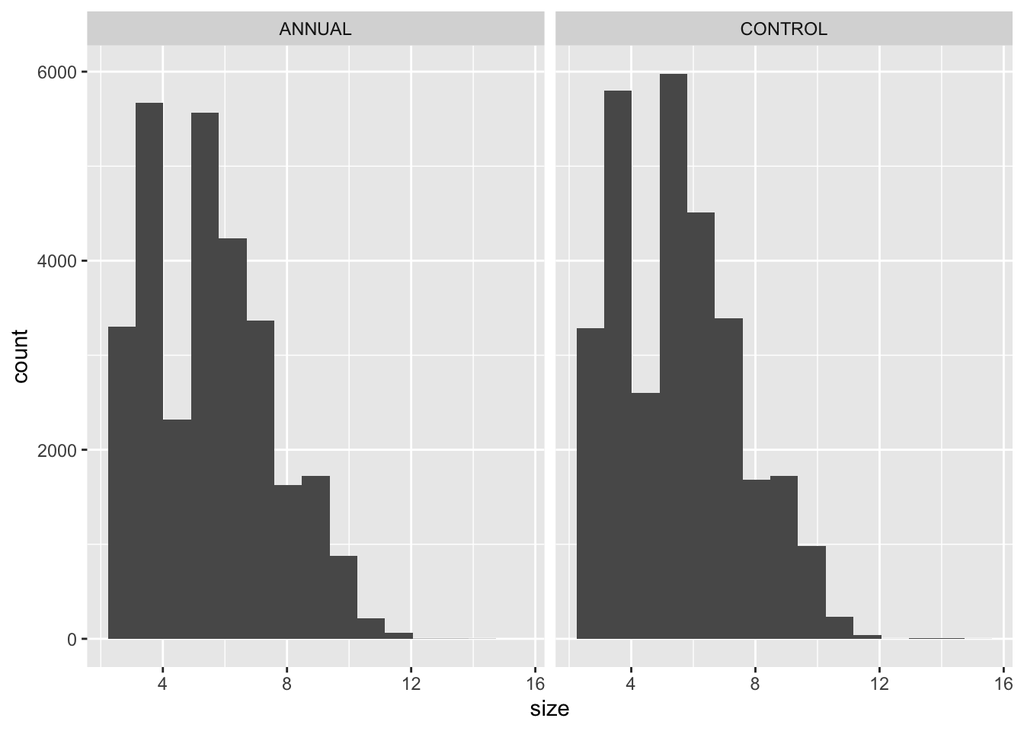

```r
 # making a exploratory graphs

# exploratory histogram

ggplot(purple_urchins_clean, aes(x = size)) +
  geom_histogram(bins = 15) +
  facet_wrap("treatment") # separating the graphs by treatment
```

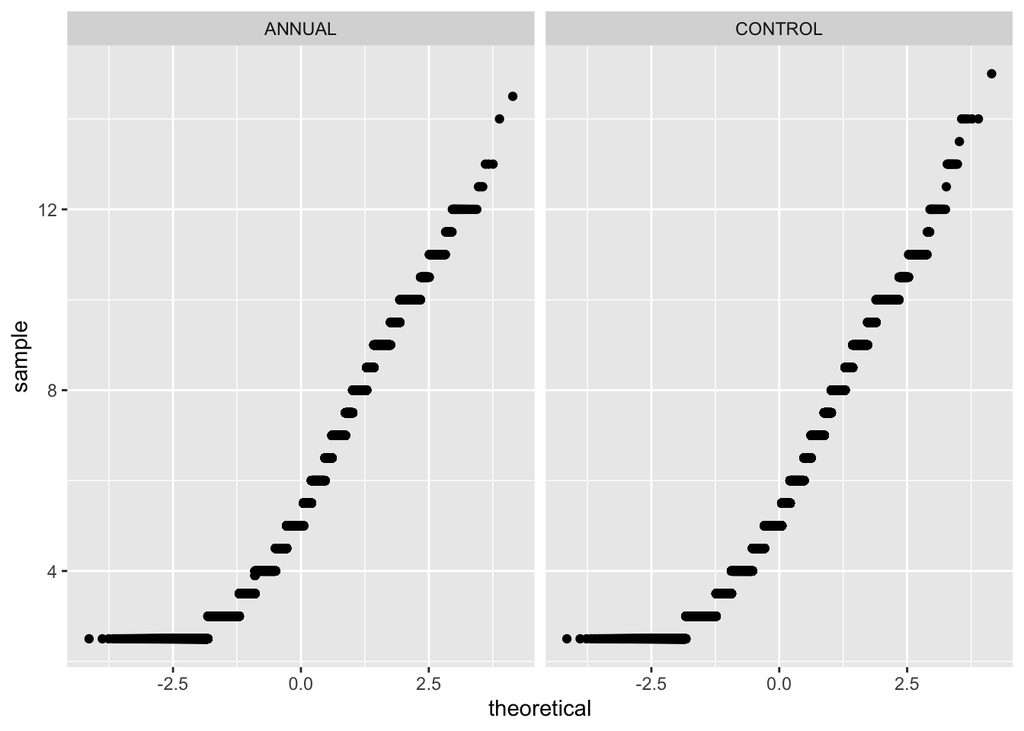

```r
# exploratory qq plot

ggplot(purple_urchins_clean, aes(sample = size)) + # making the qq plot based on urchin size
  geom_qq() +
  facet_wrap(~treatment) # separating by treatment
```

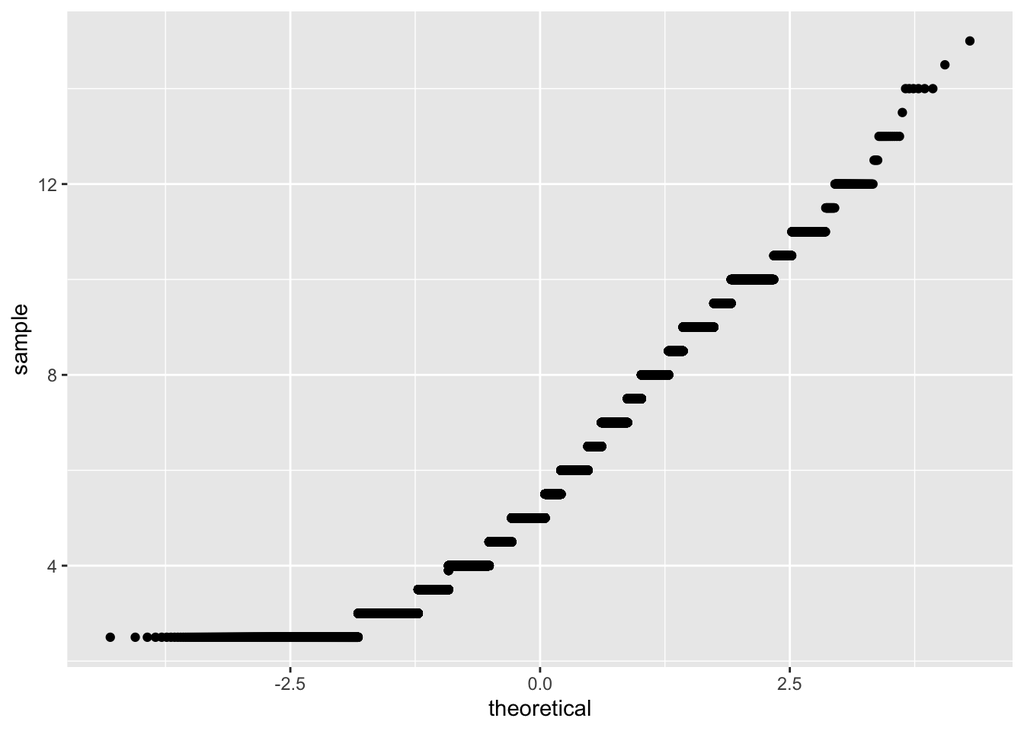

```r
ggplot(purple_urchins_clean, aes(sample = size)) + # making the qq plot based on urchin size, with both populations considered together
  geom_qq()
```

#### Exploratory graphs analysis

This histogram shows us that the distributions are relatively similar, with the majority of sizes falling between 2 and 7 centimeters. The qqplot shows a straight line when both sets of data came from the normal distributions, comparing each set of data to see if they are from the same distribution. Here, the line is lower at the beginning of the graph, and slightly tapers off towards the end on the right side. This means that the distributions likely peaked in the middle compared to a normal-curve distribution. However, this trend is seen in both treatments of urchin population, meaning that each population likely follows this distribution.

### Summary Table of Purple Urchin Population Statistics

Summary statistics on the Purple Urchins using code to generate a table.

```r
# summary stats table
purple_urchins_stats <- purple_urchins_clean %>%
  group_by(treatment) %>% # separating by treatment
  summarize( # summarizing main data points
    mean_size = mean(size),
    sd_size = sd(size),
    sample_size = n())

final_stats <- purple_urchins_stats %>%
  rename("Mean Size(cm)" = mean_size, # rename colums for clarity
         "Standard Deviation" = sd_size,
         "Sample Size" = sample_size)

# finalizing stats table

kable(final_stats, caption = "Table 1: Statistics on Purple Urchin Size by treatment at Naples Reef site", digits = 3, align = "c") # making table tidy and editing sig figs
```

Table 1: Statistics on Purple Urchin Size by treatment at Naples Reef site

| treatment | Mean Size(cm) | Standard Deviation | Sample Size |
| --- | --- | --- | --- |
| ANNUAL | 5.533 | 1.935 | 28961 |
| CONTROL | 5.542 | 1.923 | 30252 |